# **Relación entre desempleo, consumo de psicofármacos y gasto sanitario público**

Elena Diez y Amaia Bolaños

2026-11-30

## 1. Introducción del seminario

El desempleo es uno de los principales determinantes sociales de la salud. Diferentes estudios han demostrado que la falta de trabajo no solo afecta a los ingresos económicos, sino que también afecta a nivel psicológico, aumentando los niveles de ansiedad, estrés y depresión en la población. Ante esta situación, el consumo de psicofármacos (como ansiolíticos e hipnosedantes) es una de las principales respuestas médicas para tratar estos síntomas.

Lo que sabemos es que existe una tendencia en el consumo de estos medicamentos en España, y que la asistencia a los servicios de salud mental ha crecido en los últimos años. También sabemos que el sistema sanitario español está descentralizado, lo que provoca que cada Comunidad Autónoma gestione su presupuesto de manera diferente, generando desigualdades en el gasto sanitario.

Lo que no sabemos con certeza es hasta qué punto la inversión económica en sanidad influye en el impacto del paro en la salud mental.

## 2. Objetivo

### Objetivo general del seminario

Con este trabajo pretendemos estudiar si existen diferencias y asociaciones entre la tasa desempleo, el consumo de psicofármacos y el gasto sanitario público entre las comunidades autónomas españolas.

### Objetivos específicos

- Objetivo 1: Determinar si existe una correlación entre la tasa de desempleo y el consumo de psicofármacos (ansiolíticos e hipnosedantes) en las 19 Comunidades Autónomas, evaluando si el paro actúa directamente en la salud mental de la población.
- Objetivo 2: Evaluar si la inversión sanitaria influye en el consumo de psicofármacos en comunidades con tasas de desempleo similares. Determinar si un mayor gasto sanitario actúa como factor protector frente al impacto negativo del paro en la salud mental.
- Objetivo 3: Analizar si las comunidades autónomas con mayor tasa de desempleo reciben menor inversión sanitaria por habitante. Determinar si existe una brecha territorial donde las regiones más necesitadas cuentan con menos recursos para la salud.

## 3. Datos

```r
datos <- data.frame(
  # Tabla con las 19 comunidades autónomas
  CCAA = c("Andalucía", "Aragón", "Asturias", "Cantabria", "Ceuta",
         "Castilla y León", "Castilla-La Mancha", "Canarias", "Cataluña",
         "Extremadura", "Galicia", "Islas Baleares", "Región de Murcia",
         "Comunidad de Madrid", "Melilla", "Navarra", "País Vasco",
         "La Rioja", "Comunidad Valenciana"),

  # Tasa de paro por comunidad autónoma en 2026
  Tasa_Paro = c(14.6, 8.2, 9.1, 7.3, 22.4, 8.4, 11.8, 11.6, 7.9, 13.2,
                7.9, 6.1, 10.8, 7.6, 20.7, 8.1, 7.1, 8.8, 10.9),

  # Gasto sanitario por comunidad autónoma en 2026 (Ceuta y Melilla no tienen datos)
  Gasto_Sanitario = c(1870.50, 2192.92, 2506.71,  2220.03, NA, 2173.72,
                      1908.45, 2136.22, 1515.99, 2288.44, 2084.57,
                      1981.21, 1511.18, 1537.28, NA, 2275.20, 2373.27,
                      2071.19, 1586.38),

  #Consumo de psicofármacos por comunidad autónoma
  Consumo_Psicofarmacos = c(39.71, 39.19, 39.11, 63.22, 40.92, 41.13,
                            28.25, 46.84, 28.23, 35.24, 41.74, 24.56,
                            37.25, 23.17, 18.73, 40.82, 42.44, 46.15,
                            32.11)
)
```

## 4. Caracterización de las variables

Para este trabajo se han utilizado tres variables principales, todas ellas son cuantitativas continuas:

Tasa de Paro (%): Presenta una gran dispersión territorial. La media nacional se sitúa en el 10,65%, con un rango muy amplio que va desde el mínimo de Islas Baleares 6,1% hasta el máximo de Ceuta 22,4%.

```r
mean(datos$Tasa_Paro)
```

```
## [1] 10.65789
```

```r
min(datos$Tasa_Paro)
```

```
## [1] 6.1
```

```r
max(datos$Tasa_Paro)
```

```
## [1] 22.4
```

Gasto Sanitario (€/habitante): Muestra las diferencias en inversión pública en salud. La media se sitúa en 2013,72€. Destaca Asturias como la comunidad que más invierte 2506,71€, frente a Murcia, que es la que menos gasta 1511,18€. Ceuta y Melilla no tienen datos en esta variable, por lo que se han excluido.

```r
mean(datos$Gasto_Sanitario, na.rm = TRUE)
```

```
## [1] 2013.721
```

```r
max(datos$Gasto_Sanitario, na.rm = TRUE)
```

```
## [1] 2506.71
```

```r
min(datos$Gasto_Sanitario, na.rm = TRUE)
```

```
## [1] 1511.18
```

Consumo de Psicofármacos (DHD): Indica la cantidad de psicofármacos empleados en la salud mental (Dosis Diarias Definidas por cada 1.000 habitantes). La media es de 37,30 dosis. Cantabria registra el pico más alto con mucha diferencia 63,22, mientras que Melilla registra el consumo más bajo 18,7.

```r
mean(datos$Consumo_Psicofarmacos)
```

```
## [1] 37.30579
```

```r
max(datos$Consumo_Psicofarmacos)
```

```
## [1] 63.22
```

```r
min(datos$Consumo_Psicofarmacos)
```

```
## [1] 18.73
```

### Distribución de la tasa de paro y el consumo de psicofármacos en las CCAA

```r
tabla_carac_1 <- datos[order(-datos$Tasa_Paro),
                       c("CCAA", "Tasa_Paro", "Consumo_Psicofarmacos")]

options(width = 500)
print(tabla_carac_1, row.names = FALSE)
```

```
##                  CCAA Tasa_Paro Consumo_Psicofarmacos
##                 Ceuta      22.4                 40.92
##               Melilla      20.7                 18.73
##             Andalucía      14.6                 39.71
##           Extremadura      13.2                 35.24
##    Castilla-La Mancha      11.8                 28.25
##              Canarias      11.6                 46.84
##  Comunidad Valenciana      10.9                 32.11
##      Región de Murcia      10.8                 37.25
##              Asturias       9.1                 39.11
##              La Rioja       8.8                 46.15
##       Castilla y León       8.4                 41.13
##                Aragón       8.2                 39.19
##               Navarra       8.1                 40.82
##              Cataluña       7.9                 28.23
##               Galicia       7.9                 41.74
##   Comunidad de Madrid       7.6                 23.17
##             Cantabria       7.3                 63.22
##            País Vasco       7.1                 42.44
##        Islas Baleares       6.1                 24.56
```

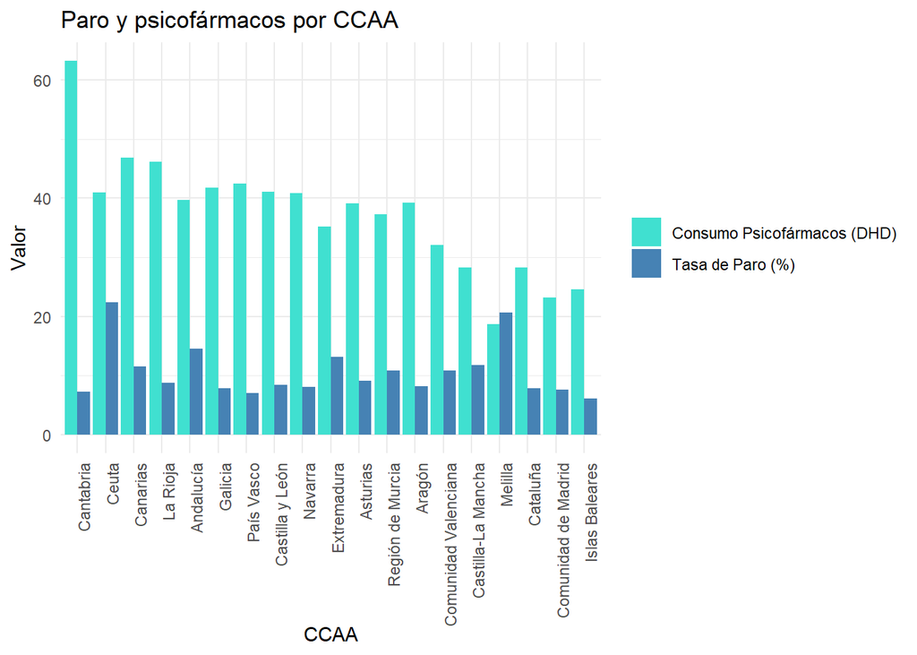

```r
datos_largos <- datos %>%
  select(CCAA, Tasa_Paro, Consumo_Psicofarmacos) %>%
  pivot_longer(-CCAA, names_to = "Variable", values_to = "Valor")

ggplot(datos_largos, aes(reorder(CCAA, -Valor), Valor, fill = Variable)) +
  geom_col(position = "dodge") +
  scale_fill_manual(values = c("turquoise", "steelblue"),
                    labels = c("Consumo Psicofármacos (DHD)", "Tasa de Paro (%)")) +
  labs(x = "CCAA", y = "Valor", fill = NULL,
       title = "Paro y psicofármacos por CCAA") +
  theme_minimal() +
  theme(axis.text.x = element_text(angle = 90, hjust = 1))
```

En cuanto al desempleo, existe una brecha enorme, por ejemplo, Ceuta (22,4%) y Melilla (20,7%) registran tasas que triplican a las de las regiones con menor paro, como Islas Baleares (6,1%) o País Vasco (7,1%). Por otro lado, el consumo de psicofármacos no sigue un patrón geográfico alineado con el paro. Comunidades como Cantabria presentan el consumo más alto de España (63,22 DHD) a pesar de tener una tasa de paro baja (7,3%); mientras que otras regiones con paro alto, como Melilla, registran el consumo más bajo.

### ¿Existen diferencias territoriales significativas en el gasto sanitario por habitante en España?

```r
tabla_carac_2 <- datos[order(-datos$Gasto_Sanitario),
                       c("CCAA", "Gasto_Sanitario")]

options(width = 500)
print(tabla_carac_2, row.names = FALSE)
```

```
##                  CCAA Gasto_Sanitario
##              Asturias         2506.71
##            País Vasco         2373.27
##           Extremadura         2288.44
##               Navarra         2275.20
##             Cantabria         2220.03
##                Aragón         2192.92
##       Castilla y León         2173.72
##              Canarias         2136.22
##               Galicia         2084.57
##              La Rioja         2071.19
##        Islas Baleares         1981.21
##    Castilla-La Mancha         1908.45
##             Andalucía         1870.50
##  Comunidad Valenciana         1586.38
##   Comunidad de Madrid         1537.28
##              Cataluña         1515.99
##      Región de Murcia         1511.18
##                 Ceuta              NA
##               Melilla              NA
```

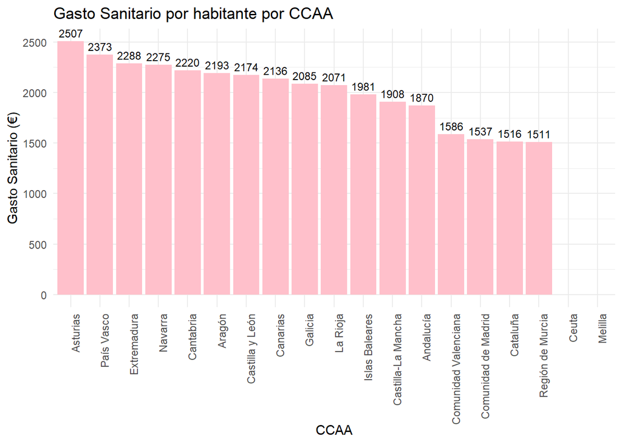

```r
ggplot(datos, aes(reorder(CCAA, -Gasto_Sanitario), Gasto_Sanitario)) +
  geom_col(fill = "pink") +
  geom_text(aes(label = round(Gasto_Sanitario)), vjust = -0.5, size = 3) +
  labs(title = "Gasto Sanitario por habitante por CCAA",
       x = "CCAA", y = "Gasto Sanitario (€)") +
  theme_minimal() +
  theme(axis.text.x = element_text(angle = 90, hjust = 1))
```

Podemos observar que si que existen diferencias territoriales muy significativas. Una persona en Asturias recibe casi 1.000€ más al año en inversión sanitaria pública que una persona en Murcia. Esto puede generar desigualdades en la calidad de la atención y en la prevención de enfermedades.

## PREGUNTA 1: ¿Existe relación entre paro y psicofármacos?

```r
# 1. Tabla ordenada por paro
tabla_resumen <- datos[order(-datos$Tasa_Paro),
                       c("CCAA", "Tasa_Paro", "Gasto_Sanitario", "Consumo_Psicofarmacos")]
options(width = 500)
print(tabla_resumen, row.names = FALSE)
```

```
##                  CCAA Tasa_Paro Gasto_Sanitario Consumo_Psicofarmacos
##                 Ceuta      22.4              NA                 40.92
##               Melilla      20.7              NA                 18.73
##             Andalucía      14.6         1870.50                 39.71
##           Extremadura      13.2         2288.44                 35.24
##    Castilla-La Mancha      11.8         1908.45                 28.25
##              Canarias      11.6         2136.22                 46.84
##  Comunidad Valenciana      10.9         1586.38                 32.11
##      Región de Murcia      10.8         1511.18                 37.25
##              Asturias       9.1         2506.71                 39.11
##              La Rioja       8.8         2071.19                 46.15
##       Castilla y León       8.4         2173.72                 41.13
##                Aragón       8.2         2192.92                 39.19
##               Navarra       8.1         2275.20                 40.82
##              Cataluña       7.9         1515.99                 28.23
##               Galicia       7.9         2084.57                 41.74
##   Comunidad de Madrid       7.6         1537.28                 23.17
##             Cantabria       7.3         2220.03                 63.22
##            País Vasco       7.1         2373.27                 42.44
##        Islas Baleares       6.1         1981.21                 24.56
```

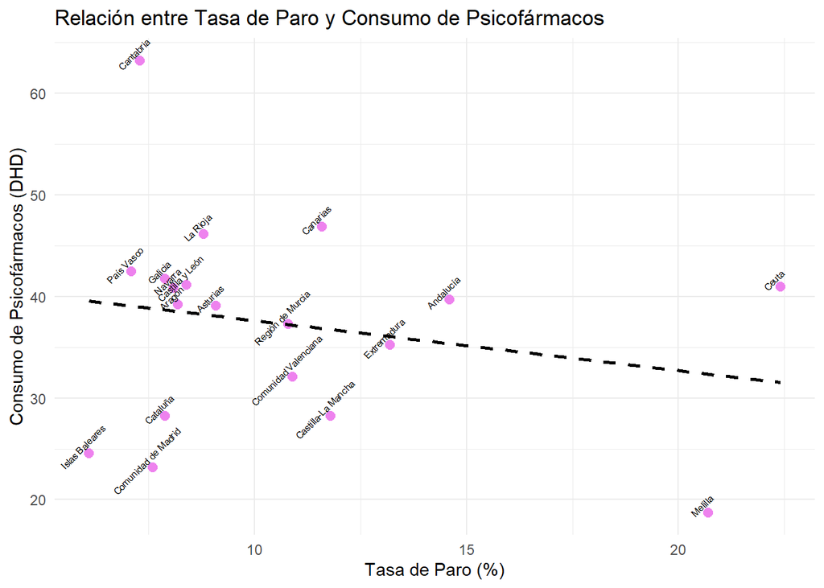

```r
# 2. Gráfico
ggplot(datos, aes(x = Tasa_Paro, y = Consumo_Psicofarmacos)) +
  geom_point(color = "violet", size = 2.5) +
  geom_smooth(method = "lm", se = FALSE, color = "black", linetype = "dashed") +
  geom_text(aes(label = CCAA), vjust = -0.8, size = 2, angle = 45) +
  labs(title = "Relación entre Tasa de Paro y Consumo de Psicofármacos",
       x = "Tasa de Paro (%)",
       y = "Consumo de Psicofármacos (DHD)") +
  theme_minimal()
```

## PREGUNTA 2: ¿El gasto sanitario modula el efecto del paro sobre el consumo?

```r
# 1. Tabla: Filtramos las CCAA con paro entre 9% y 15% (paro similar)
tabla_p3 <- datos[datos$Tasa_Paro >= 9 & datos$Tasa_Paro <= 15,
                  c("CCAA", "Tasa_Paro", "Gasto_Sanitario", "Consumo_Psicofarmacos")]

# Ordenamos la tabla por gasto sanitario (de mayor a menor)
tabla_p3 <- tabla_p3[order(-tabla_p3$Gasto_Sanitario), ]
options(width = 500)
print(tabla_p3, row.names = FALSE)
```

```
##                  CCAA Tasa_Paro Gasto_Sanitario Consumo_Psicofarmacos
##              Asturias       9.1         2506.71                 39.11
##           Extremadura      13.2         2288.44                 35.24
##              Canarias      11.6         2136.22                 46.84
##    Castilla-La Mancha      11.8         1908.45                 28.25
##             Andalucía      14.6         1870.50                 39.71
##  Comunidad Valenciana      10.9         1586.38                 32.11
##      Región de Murcia      10.8         1511.18                 37.25
```

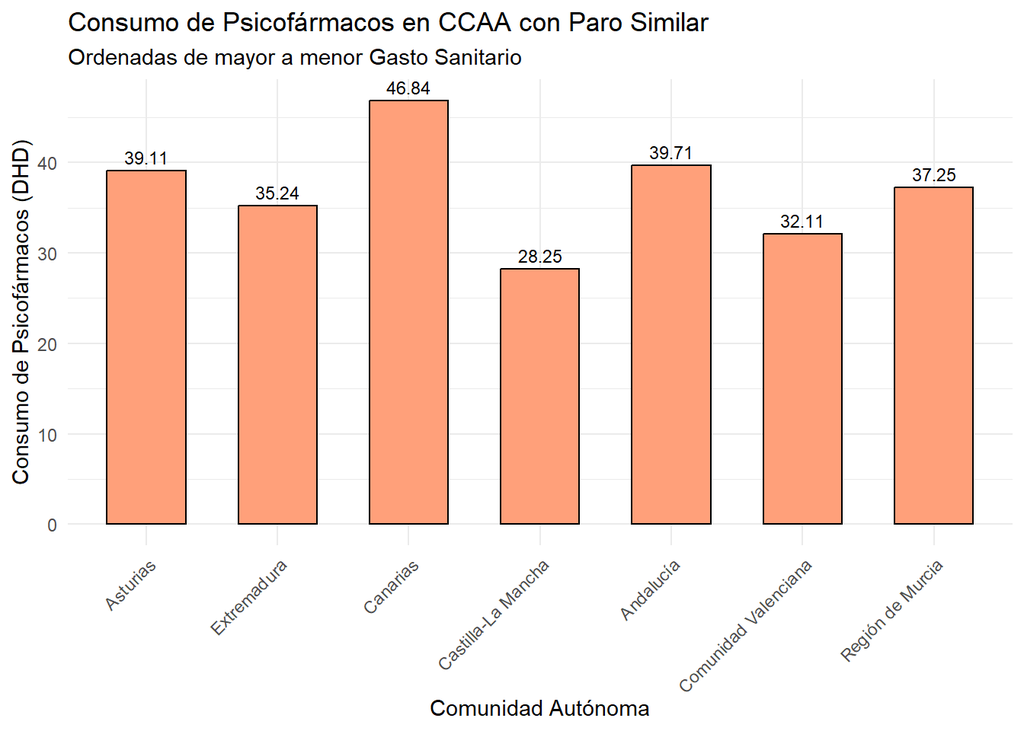

```r
# 2. Gráfico de barras
ggplot(tabla_p3, aes(x = reorder(CCAA, -Gasto_Sanitario), y = Consumo_Psicofarmacos)) +
  geom_bar(stat = "identity", fill = "lightsalmon", colour = "black", width = 0.6) +
  geom_text(aes(label = Consumo_Psicofarmacos), vjust = -0.5, size = 3) +
  labs(title = "Consumo de Psicofármacos en CCAA con Paro Similar",
       subtitle = "Ordenadas de mayor a menor Gasto Sanitario",
       x = "Comunidad Autónoma",
       y = "Consumo de Psicofármacos (DHD)") +
  theme_minimal() +
  theme(axis.text.x = element_text(angle = 45, hjust = 1))
```

## PREGUNTA 3: ¿Las CCAA con más paro gastan menos en sanidad?

```r
# 1. Tabla ordenada por paro
tabla_resumen <- datos[order(-datos$Tasa_Paro),
                       c("CCAA", "Tasa_Paro", "Gasto_Sanitario")]
options(width = 500)
print(tabla_resumen, row.names = FALSE)
```

```
##                  CCAA Tasa_Paro Gasto_Sanitario
##                 Ceuta      22.4              NA
##               Melilla      20.7              NA
##             Andalucía      14.6         1870.50
##           Extremadura      13.2         2288.44
##    Castilla-La Mancha      11.8         1908.45
##              Canarias      11.6         2136.22
##  Comunidad Valenciana      10.9         1586.38
##      Región de Murcia      10.8         1511.18
##              Asturias       9.1         2506.71
##              La Rioja       8.8         2071.19
##       Castilla y León       8.4         2173.72
##                Aragón       8.2         2192.92
##               Navarra       8.1         2275.20
##              Cataluña       7.9         1515.99
##               Galicia       7.9         2084.57
##   Comunidad de Madrid       7.6         1537.28
##             Cantabria       7.3         2220.03
##            País Vasco       7.1         2373.27
##        Islas Baleares       6.1         1981.21
```

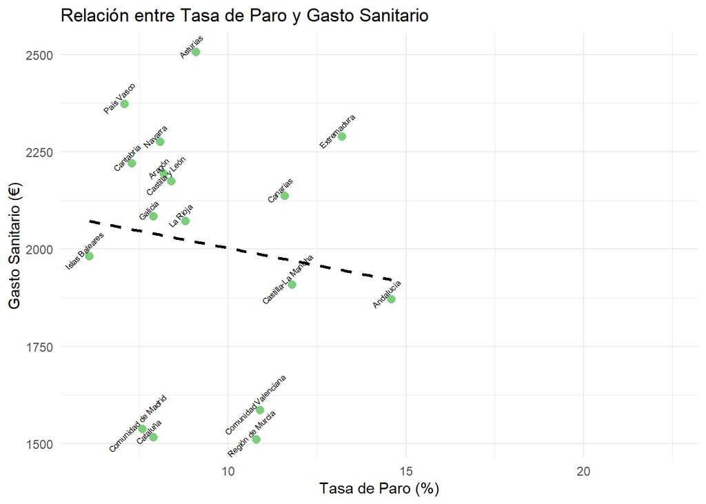

```r
# 2. Gráfico (solución gráfica)
ggplot(datos, aes(x = Tasa_Paro, y = Gasto_Sanitario)) +
  geom_point(color = "palegreen3", size = 2.5) +
  geom_smooth(method = "lm", se = FALSE, color = "black", linetype = "dashed") +
  geom_text(aes(label = CCAA), vjust = -0.8, size = 2, angle = 45) +
  labs(title = "Relación entre Tasa de Paro y Gasto Sanitario",
       x = "Tasa de Paro (%)", y = "Gasto Sanitario (€)") +
  theme_minimal()
```

## 5. Conclusión final

En conclusión, con este trabajo hemos podido observar que existen diferencias importantes entre las comunidades autónomas españolas en cuanto al desempleo, el consumo de psicofármacos y el gasto sanitario público. Los resultados muestran que aunque existe relación entre el paro y en consumo hay más factores que influyen. Por otro lado, hemos observado que el gasto sanitario puede influir en la atención a la salud mental. También se han encontrado diferencias importantes en la inversión sanitaria entre comunidades, lo que puede generar desigualdades en el acceso a los recursos y a la atención sanitaria. Finalmente, este análisis nos ha permitido comprender que la salud mental depende de diferentes factores sociales y económicos, y que es importante reducir las desigualdades entre comunidades autónomas para garantizar una atención sanitaria más igualitaria.